# AIProject2

```python
import pandas as pd
#settings :
pd.set_option('display.max_rows', 1000)
pd.set_option('display.max_columns', 500)
pd.set_option('display.width', 1000)
pd.set_option('display.max_colwidth', 1000)
import numpy as np
import matplotlib.pyplot as plt
import seaborn as sns #pip install seaborn
import missingno as msno
#import datatable as dt  # pip install datatble
import datetime
```

Sara materials from Moodle/lessons

Riikka Formulahti 2003088 NAI20SP, made initially on Kaggle

https://www.kaggle.com/c/competitive-data-science-predict-future-sales/

```python
#data = pd.read_csv('../input/alldatacompetitiontwo/all_data_competition2.csv')
data = pd.read_csv('all_data_competition2.csv')
```

```python
data.head(5)
```

|  | date | date_block_num | shop_id | item_id | item_price | item_cnt_day | item_name | item_category_id | item_category_name | shop_name | region_name | region_id |
| --- | --- | --- | --- | --- | --- | --- | --- | --- | --- | --- | --- | --- |
| 0 | 02.01.2013 | 0 | 59 | 22154 | 999.00 | 1.0 | Scene 2012 (BD) | 37 | Movies - Blu-Ray | Yaroslavl shopping center "Altair" | Central Federal District | 1 |
| 1 | 03.01.2013 | 0 | 25 | 2552 | 899.00 | 1.0 | DEEP PURPLE The House Of Blue Light LP | 58 | Music - Vinyl | Moscow TRC "Atrium" | Moscow and Moscow Oblast | 8 |
| 2 | 05.01.2013 | 0 | 25 | 2552 | 899.00 | -1.0 | DEEP PURPLE The House Of Blue Light LP | 58 | Music - Vinyl | Moscow TRC "Atrium" | Moscow and Moscow Oblast | 8 |
| 3 | 06.01.2013 | 0 | 25 | 2554 | 1709.05 | 1.0 | DEEP PURPLE Who Do You Think We Are LP | 58 | Music - Vinyl | Moscow TRC "Atrium" | Moscow and Moscow Oblast | 8 |
| 4 | 15.01.2013 | 0 | 25 | 2555 | 1099.00 | 1.0 | DEEP PURPLE 30 Very Best Of 2CD (Фирм.) | 56 | Music - CD production firm | Moscow TRC "Atrium" | Moscow and Moscow Oblast | 8 |

# lesson 1 things

```python
data.describe().T
```

|  | count | mean | std | min | 25% | 50% | 75% | max |
| --- | --- | --- | --- | --- | --- | --- | --- | --- |
| date_block_num | 2935849.0 | 14.569911 | 9.422988 | 0.0 | 7.0 | 14.0 | 23.0 | 33.0 |
| shop_id | 2935849.0 | 33.001728 | 16.226973 | 0.0 | 22.0 | 31.0 | 47.0 | 59.0 |
| item_id | 2935849.0 | 10197.227057 | 6324.297354 | 0.0 | 4476.0 | 9343.0 | 15684.0 | 22169.0 |
| item_price | 2935849.0 | 890.853233 | 1729.799631 | -1.0 | 249.0 | 399.0 | 999.0 | 307980.0 |
| item_cnt_day | 2935849.0 | 1.242641 | 2.618834 | -22.0 | 1.0 | 1.0 | 1.0 | 2169.0 |
| item_category_id | 2935849.0 | 40.001383 | 17.100759 | 0.0 | 28.0 | 40.0 | 55.0 | 83.0 |
| region_id | 2935849.0 | 5.789265 | 2.653943 | 1.0 | 4.0 | 7.0 | 8.0 | 9.0 |

```python
data.info()
```

```
<class 'pandas.core.frame.DataFrame'>
RangeIndex: 2935849 entries, 0 to 2935848
Data columns (total 12 columns):
 #   Column              Dtype
---  ------              -----
 0   date                object
 1   date_block_num      int64
 2   shop_id             int64
 3   item_id             int64
 4   item_price          float64
 5   item_cnt_day        float64
 6   item_name           object
 7   item_category_id    int64
 8   item_category_name  object
 9   shop_name           object
 10  region_name         object
 11  region_id           int64
dtypes: float64(2), int64(5), object(5)
memory usage: 268.8+ MB
```

```python
len(data['item_id'].unique())
```

```
21807
```

```python
len(data['shop_id'].unique())
```

```
60
```

```python
len(data['date_block_num'].unique())
```

```
34
```

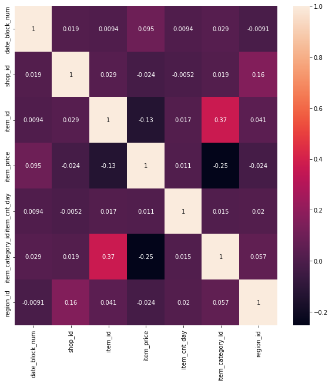

```python
corr = data.corr()
highly_corr_features = corr.index[abs(corr["item_cnt_day"])>0.0]
plt.figure(figsize=(10,10))
map = sns.heatmap(data[highly_corr_features].corr(),annot=True)
```

```python
#month 0
data_month_0 = data[data['date_block_num']==0]
len(data_month_0)
```

```
115690
```

```python
#month 1
data_month_1 = data[data['date_block_num']==1]
len(data_month_1)
```

```
108613
```

# lesson 2 things

```
Convert strings to datetime
Get year, month and day
Get days of week
```

```python
data.dtypes
```

```
date                   object
date_block_num          int64
shop_id                 int64
item_id                 int64
item_price            float64
item_cnt_day          float64
item_name              object
item_category_id        int64
item_category_name     object
shop_name              object
region_name            object
region_id               int64
dtype: object
```

pandas.to_datetime(arg, errors='raise', dayfrist=False, yearfirst=False, utc=None, format=None, exact=True, unit=None, infer_datatime_format=False, origin='unit', cache=True)

%timeit pd.to_datetime(s, infer_datatime_format=True) 100 loops, best of 3: 10.3ms per loop

```python
data['date'] = pd.to_datetime(data['date'], infer_datetime_format=True)
```

```python
data.dtypes
```

```
date                  datetime64[ns]
date_block_num                 int64
shop_id                        int64
item_id                        int64
item_price                   float64
item_cnt_day                 float64
item_name                     object
item_category_id               int64
item_category_name            object
shop_name                     object
region_name                   object
region_id                      int64
dtype: object
```

pandas.DatetimeIndex.dayofweek

return day of week, start day Monday = 0, Sunday = 6. using dt accessor or DatatimeIndex. returns: series or index, containing integers indicating day number

https://pandas.pydata.org/docs/reference/api/pandas.DatetimeIndex.dayofweek.html

```python
data['week']= data['date'].dt.dayofweek
```

```python
data.head()
```

|  | date | date_block_num | shop_id | item_id | item_price | item_cnt_day | item_name | item_category_id | item_category_name | shop_name | region_name | region_id | week |
| --- | --- | --- | --- | --- | --- | --- | --- | --- | --- | --- | --- | --- | --- |
| 0 | 2013-02-01 | 0 | 59 | 22154 | 999.00 | 1.0 | Scene 2012 (BD) | 37 | Movies - Blu-Ray | Yaroslavl shopping center "Altair" | Central Federal District | 1 | 4 |
| 1 | 2013-03-01 | 0 | 25 | 2552 | 899.00 | 1.0 | DEEP PURPLE The House Of Blue Light LP | 58 | Music - Vinyl | Moscow TRC "Atrium" | Moscow and Moscow Oblast | 8 | 4 |
| 2 | 2013-05-01 | 0 | 25 | 2552 | 899.00 | -1.0 | DEEP PURPLE The House Of Blue Light LP | 58 | Music - Vinyl | Moscow TRC "Atrium" | Moscow and Moscow Oblast | 8 | 2 |
| 3 | 2013-06-01 | 0 | 25 | 2554 | 1709.05 | 1.0 | DEEP PURPLE Who Do You Think We Are LP | 58 | Music - Vinyl | Moscow TRC "Atrium" | Moscow and Moscow Oblast | 8 | 5 |
| 4 | 2013-01-15 | 0 | 25 | 2555 | 1099.00 | 1.0 | DEEP PURPLE 30 Very Best Of 2CD (Фирм.) | 56 | Music - CD production firm | Moscow TRC "Atrium" | Moscow and Moscow Oblast | 8 | 1 |

```python
data['week'].value_counts()
```

```
5    537372
6    471404
4    435267
1    375927
2    375151
3    372591
0    368137
Name: week, dtype: int64
```

```python
data['day'] = data['date'].dt.day
data['month'] = data['date'].dt.month
data['year'] = data['date'].dt.year
```

```python
data.head()
```

|  | date | date_block_num | shop_id | item_id | item_price | item_cnt_day | item_name | item_category_id | item_category_name | shop_name | region_name | region_id | week | day | month | year |
| --- | --- | --- | --- | --- | --- | --- | --- | --- | --- | --- | --- | --- | --- | --- | --- | --- |
| 0 | 2013-02-01 | 0 | 59 | 22154 | 999.00 | 1.0 | Scene 2012 (BD) | 37 | Movies - Blu-Ray | Yaroslavl shopping center "Altair" | Central Federal District | 1 | 4 | 1 | 2 | 2013 |
| 1 | 2013-03-01 | 0 | 25 | 2552 | 899.00 | 1.0 | DEEP PURPLE The House Of Blue Light LP | 58 | Music - Vinyl | Moscow TRC "Atrium" | Moscow and Moscow Oblast | 8 | 4 | 1 | 3 | 2013 |
| 2 | 2013-05-01 | 0 | 25 | 2552 | 899.00 | -1.0 | DEEP PURPLE The House Of Blue Light LP | 58 | Music - Vinyl | Moscow TRC "Atrium" | Moscow and Moscow Oblast | 8 | 2 | 1 | 5 | 2013 |
| 3 | 2013-06-01 | 0 | 25 | 2554 | 1709.05 | 1.0 | DEEP PURPLE Who Do You Think We Are LP | 58 | Music - Vinyl | Moscow TRC "Atrium" | Moscow and Moscow Oblast | 8 | 5 | 1 | 6 | 2013 |
| 4 | 2013-01-15 | 0 | 25 | 2555 | 1099.00 | 1.0 | DEEP PURPLE 30 Very Best Of 2CD (Фирм.) | 56 | Music - CD production firm | Moscow TRC "Atrium" | Moscow and Moscow Oblast | 8 | 1 | 15 | 1 | 2013 |

```python
all_dataset = []
for month in range(34):
        dataset_each = data.loc[data['date_block_num'] == month]
        all_dataset.append(dataset_each)
```

```python
month0,month1,month2,month3,month4,month5,month6,month7,month8,month9,month10,month11,month12,month13,month14,month15,month16,month17,month18,month19,month20,month21,month22,month23,month24,month25,month26,month27,month28,month29,month30,month31,month32,month33=all_dataset
```

# lesson 2 compulsory task1

TASK DESCRIPTION :

1. Create a new dichotomic column with value 1 if the date is a national holliday in Russia otherwise 0

These steps might help you :

1. Find all national hollidays for different years in Russia.
2. (Manually) create a Python list with all the national hollidays for different years as pd.datetime
3. Iterate through the pandas dataframe by using .loc([condition]) and check if the date can be found from the Python list with the national hollidays. If so, assign a value 1 to a new column "nat_hollidays_dich", if not assign value 0

```python
# https://www.timeanddate.com/holidays/russia/2013

#2013:
#JAN 1,2,3,4,7,8,14,24
#FEB 14,23
#MAR 8,20
#MAY 1,2,3,5,9,10
#JUN 6,12,21
#JUL 9
#AUG 3,8
#SEP 1,23
#OCT 15
#NOV 4,5
#DEC 21,30,31

#2014:
#JAN 1,2,3,4,5,6,7,8,14,24
#FEB 14,22,23
#MAR 8,9,10,20
#APR 20
#MAY 1,2,3,4,5,9,10,11,27
#JUN 7,12,13,14,15,21
#JUL 24,29
#SEP 1,23
#OCT 4,25
#NOV 1,2,3,4
#DEC 22

#2015
#JAN 1,2,3,4,5,6,7,8,9,14
#FEB 14,23,27
#MAR 8,9,21
#APR 12
#MAY 1,4,9,11,16
#JUN 12,18,21
#JUL 13,18
#SEP 1,23,24
#OCT 15

#stops at OCT since data in file stops there
```

```python
# 2

# data from January 2013 to October 2015

# ran out of time, but maybe got Jupyter Lab working after 1.5 years... to get html file out

# https://stackoverflow.com/questions/34428678/convert-list-to-datetime-in-pandas

# pd.to_datetime(pd.Series(s) + '_2015', format='%b_%d_%Y')
```

```python
# 3
```

# Sara's code from lesson3

```python
data['date'] = pd.to_datetime(data['date'], dayfirst=True)
```

```python
from datetime import date
import holidays

#pip install holidays
```

```python
russia_holidays = holidays.Russia()
```

```python
russia_holidays
```

```
holidays.CountryHoliday('RU')
```

```python
holidays.CountryHoliday('RU')
```

```
holidays.CountryHoliday('RU')
```

```python
holidays_list = []
for date, name in sorted(holidays.RU(years=2013).items()):
    holidays_list.append(date)
for date, name in sorted(holidays.RU(years=2014).items()):
    holidays_list.append(date)
for date, name in sorted(holidays.RU(years=2015).items()):
    holidays_list.append(date)
```

```python
holidays_list
```

```
[datetime.date(2013, 1, 1),
 datetime.date(2013, 1, 2),
 datetime.date(2013, 1, 3),
 datetime.date(2013, 1, 4),
 datetime.date(2013, 1, 5),
 datetime.date(2013, 1, 6),
 datetime.date(2013, 1, 7),
 datetime.date(2013, 1, 8),
 datetime.date(2013, 2, 23),
 datetime.date(2013, 3, 8),
 datetime.date(2013, 5, 1),
 datetime.date(2013, 5, 9),
 datetime.date(2013, 6, 12),
 datetime.date(2013, 11, 4),
 datetime.date(2014, 1, 1),
 datetime.date(2014, 1, 2),
 datetime.date(2014, 1, 3),
 datetime.date(2014, 1, 4),
 datetime.date(2014, 1, 5),
 datetime.date(2014, 1, 6),
 datetime.date(2014, 1, 7),
 datetime.date(2014, 1, 8),
 datetime.date(2014, 2, 23),
 datetime.date(2014, 3, 8),
 datetime.date(2014, 5, 1),
 datetime.date(2014, 5, 9),
 datetime.date(2014, 6, 12),
 datetime.date(2014, 11, 4),
 datetime.date(2015, 1, 1),
 datetime.date(2015, 1, 2),
 datetime.date(2015, 1, 3),
 datetime.date(2015, 1, 4),
 datetime.date(2015, 1, 5),
 datetime.date(2015, 1, 6),
 datetime.date(2015, 1, 7),
 datetime.date(2015, 1, 8),
 datetime.date(2015, 2, 23),
 datetime.date(2015, 3, 8),
 datetime.date(2015, 5, 1),
 datetime.date(2015, 5, 9),
 datetime.date(2015, 6, 12),
 datetime.date(2015, 11, 4)]
```

```python
data['holidays'] = data['date'].isin(holidays_list)
data.head()
```

[output not shown]

```python
data['holidays'] = data['holidays'].replace(False, 0)
data.head()
```

[output not shown]

# Lesson 3 task

Linear Regression from sklearn.linear_model import LinearRegression

LGBM Regressor from lightgbm import LGBMRegressor

XGBoost Regressor from xgboost.sklearn import XGBRegressor

```python
from sklearn.linear_model import LinearRegression
from lightgbm import LGBMRegressor
```

```python
from xgboost.sklearn import XGBRegressor
```

[output not shown]

```python
#https://towardsdatascience.com/linear-regression-in-6-lines-of-python-5e1d0cd05b8d
X = data.iloc[:, 0].values.reshape(-1, 1)  # values converts it into a numpy array
Y = data.iloc[:, 1].values.reshape(-1, 1)  # -1 means that calculate the dimension of rows, but have 1 column
linear_regressor = LinearRegression()  # create object for the class
linear_regressor.fit(X, Y)  # perform linear regression
Y_pred = linear_regressor.predict(X)  # make predictions
```

[output not shown]

[output not shown]

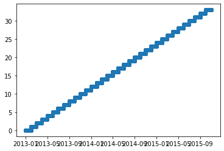

```python
#visualize
plt.scatter(X, Y)
plt.plot(X, Y_pred, color='red')
plt.show()
```

# Lesson 5

Sara code from Moodle: Code sum item_id by month and shop_id

```python
import warnings
warnings.filterwarnings('ignore')

from sklearn.metrics import mean_squared_error
import warnings
warnings.filterwarnings('ignore')
```

```python
%time
#data =pd.read_csv('all_competition_final.csv')
```

```
CPU times: user 5 µs, sys: 1 µs, total: 6 µs
Wall time: 13.1 µs
```

```python
data.head()
```

[output not shown]

```python
columns = data.columns.to_list()
print(columns)
```

[output not shown]

```python
# this code sum the values of item_cnt_day by first: date_block_num(month), second: shop_id, Third: idem_id
group_train = data.groupby(by=['date_block_num', 'shop_id','item_category_id'], ).agg({'item_cnt_day':sum}).reset_index()
group_train.head()
```

|  | date_block_num | shop_id | item_category_id | item_cnt_day |
| --- | --- | --- | --- | --- |
| 0 | 0 | 0 | 2 | 53.0 |
| 1 | 0 | 0 | 3 | 28.0 |
| 2 | 0 | 0 | 4 | 16.0 |
| 3 | 0 | 0 | 5 | 28.0 |
| 4 | 0 | 0 | 6 | 65.0 |

```python
# this is what the code does with each one of the the dimensions
# for example:  item_id = 28 in the month 0 were sold 4589 times.
item_28 = data.loc[data['item_category_id']==28]
item_28_month0 = item_28.loc[item_28['date_block_num']==0]
print("Item_id= 28 month= 0 sold" ,len(item_28_month0))
item_28_shop_id = item_28_month0.loc[item_28_month0['shop_id']==0]
print("shop_id with the Id=0 sold in a month ", len(item_28_shop_id) ,'itens with the id=28')
```

```
Item_id= 28 month= 0 sold 4589
shop_id with the Id=0 sold in a month  134 itens with the id=28
```

```python
item_28_month0 = data.loc[data['date_block_num']==0]
```

```python
group_train.rename(columns = {'item_cnt_day':'item_cnt_month'}, inplace = True)
```

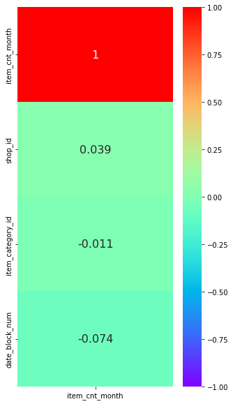

```python
top_features = group_train.corr()[['item_cnt_month']].sort_values(by=['item_cnt_month'],ascending=False).head(30)
plt.figure(figsize=(5,10))
sns.heatmap(top_features,cmap='rainbow',annot=True,annot_kws={"size": 16},vmin=-1)
```

```python
#extra codes :

# Drop several columns
#  data = data.drop(['date',  'item_name', 'item_category_name',  'week', 'day', 'month', 'year', 'days_week', 'shop_name', 'region_name', 'region_id'], axis=1)


# mean aggregation function
# group_train = data.groupby(by=['date_block_num', 'shop_id','item_category_id'], ).agg({'item_cnt_day':'mean'}).reset_index()
# group_train.head()
```

```python
# this code sum the values of item_cnt_day by first: date_block_num(month), second: shop_id, Third: idem_id
group_train = data.groupby(by=['date_block_num', 'shop_id','date'], ).agg({'item_cnt_day':sum}).reset_index()
group_train.head()
```

[output not shown]

```python
# this is what the code does with each one of the the dimensions
# for example:  item_id = 28 in the month 0 were sold 4589 times.
item_28 = data.loc[data['date']==28]
item_28_month0 = item_28.loc[item_28['date_block_num']==0]
print("Item_id= 28 month= 0 sold" ,len(item_28_month0))
item_28_shop_id = item_28_month0.loc[item_28_month0['shop_id']==0]
print("shop_id with the Id=0 sold in a month ", len(item_28_shop_id) ,'itens with the id=28')
```

```
Item_id= 28 month= 0 sold 0
shop_id with the Id=0 sold in a month  0 itens with the id=28
```

```python
item_28_month0 = data.loc[data['date_block_num']==0]
```

```python
group_train.rename(columns = {'item_cnt_day':'item_cnt_month'}, inplace = True)
```

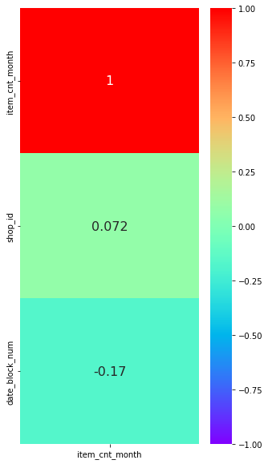

```python
top_features = group_train.corr()[['item_cnt_month']].sort_values(by=['item_cnt_month'],ascending=False).head(30)
plt.figure(figsize=(5,10))
sns.heatmap(top_features,cmap='rainbow',annot=True,annot_kws={"size": 16},vmin=-1)
```